# Photoresistor Data Collection

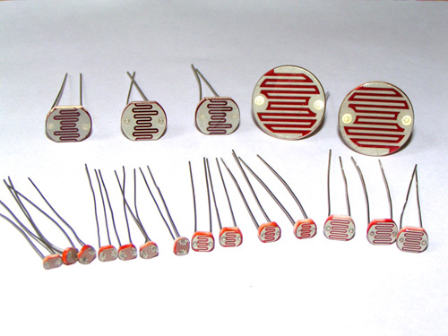

## Photoresistor Basics

A photoresistor is a light dependent resistor (LDR) which may sometimes be referred to as a photocell. The device behaves like a normal resistor except that its resistance changes with the light that it is exposed to. It is important to note that the resistance changes due to the illuminance of the light source. Illuminance has units of $lux$ ($cd \cdot sr \cdot m^{-2}$) and is the total luminous flux that occurs on the surface of the photoresistor. Luminous flux has units of $lumen$ ($cd \cdot sr$) and is sometimes referred to as luminous power. It is the measured perceived power of light. It incorporates all the various intensities and magnitudes of the different wavelengths (i.e. different colors) of a particular light source. This is worth mentioning because often times photoresistors are erroneously used to measure different wavelengths of light. A photoresistor cannot simply be used to measure a particular wavelength of light. There are numerous other parameters that must be taken into account when trying to accomplish that goal. There are two common schematic symbols used to represent the photoresistor. They are shown below in Figure 1.

Figure 1: Photoresistor Schematic Symbols

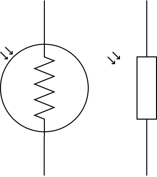

The symbol resembles that of a typical resistor with the addition of a set of double arrows pointed towards the center of the body of the resistor symbol. This is meant to emphasize the point that the resistor is light dependent. The basic structure of a photoresistor is shown below in Figure 2.

Figure 2: Photoresistor Anatomy

[figure not shown]

The photoresistor consists of two metal contacts separated by an active film that is a semiconductor. The semiconductor is supported by a substrate that insulates it. As more photons strike the semiconductor, the semiconductor frees more valence electrons which allows more electrons to flow between the two metal contacts. This phenomenon is known as photoconductivity. Just like a typical resistor, photoresistors have no polarity so there is no positive or negative side of the photoresistor. There are a variety of materials that are commonly used for the semiconductors such as

- Cadmium
- Germanium
- Gallium
- Indium
- Lead
- Selenide
- Sulfide

Each of different materials provide a different sensitivity to different wavelengths. Shown below in Figure 3 is a plot showing the detectivity of various semiconductors commonly used in photoresistors.

Figure 3: Photoresistor Material Detectivity

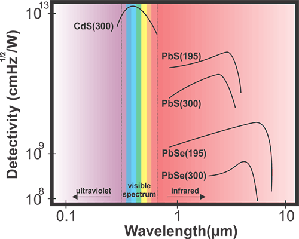

## Your Photoresistor

The photoresistor in your kit is manufactured by Luna Optoelectronics. It's part number is PDV-P8103. The photoresistor's resistance-illuminance behavior is found from the photoresistor's [datasheet](https://media.digikey.com/pdf/Data%20Sheets/Photonic%20Detetectors%20Inc%20PDFs/PDV-P8103.pdf). It is shown below in Figure 4.

Figure 4: Photoresistor Resistance-Illuminance Plot

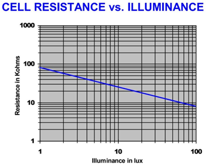

Reviewing the plot shows that there appears to be a linear relation between the resistance and illuminance. Upon closer inspection, though, it may be seen that the plot is on a $log$-$log$ scale so the typical $m x + b$ expression form may not be used to determine a mathematical function relationship between the photoresistor's resistance and the illuminance it experiences. Instead a modified form of the line expression may be used which is shown below.

$$ y = k x^m $$

where

- $k$ is the y-intercept of the line on the $log$-$log$ plot
- $m$ is the $log$ slope and is given by $$ m = \frac{\log \left(y_2\right) - \log \left(y_1\right)}{\log \left(x_2\right) - \log \left(x_1\right)} $$

Make sure that $log$ base $10$ is used and not the natural log $ln$. So for the photoresistor in your kit, the plot in Figure 4 may be used to determine an expression for the resistance-illuminance relationship. The points $p_1 = \left(1, 80\right)$ and $p_2 = \left( 100, 8 \right)$ are selected as the terminating points of the plot's line. When using a plot like this, there is no exact way to read particular points so some variation is expected between different people's interpretation of the plot. Using $p_1$, and $p_2$, the y-intercept and $log$ slope may be found. This is shown below.

$$ k = 80 $$$$ m = \frac{\log \left(y_2\right) - \log \left(y_1\right)}{\log \left(x_2\right) - \log \left(x_1\right)} = \frac{\log \left(8\right) - \log \left(80\right)}{\log \left(100\right) - \log \left(1\right)} = -0.5 $$

The mathematical relationship of the photoresistor is then

$$ y = 80 x^{-0.5} $$

or in terms of resistance $R$ in $k\Omega$ and illuminance $L$ in $lux$

$$ R = 80 L^{-0.5} $$

If the inverse relationship is desired, then this may be found by solving for illuminance $L$ which is shown below.

$$ L = \frac{6400}{R^2} $$

## Using A Photoresistor

Using a photoresistor to measure light is a similar process as using a thermistor to measure temperature. A voltage divider circuit will be used along with the Arduino `analogRead` function. All of this is straight forward. The question then becomes "What value resistance should the bias resistor be in the voltage divider circuit?" There are two lines of thought to answer this question for any voltage divider circuit.

1. Choose a bias resistor that is the mid point of the full scale range of the device's resistance.

This method allows for the voltage divider circuit to be used in a variety of measurement scenarios. It works decently well for the entire range of the full scale of the device's resistance but may not provide acceptable results for a particular region of the full scale. For the photoresistor in your kit, according to the plot in Figure 4, the full scale ranges from approximately $ 8 k\Omega $ to $ 80 k\Omega $ giving an mid point of $ 44 k\Omega $.

2. Choose a bias resistor close to the nominal value of the device's resistance.

This method maximizes relevancy to a particular measurement scenario. It may be adjusted by choosing a bias resistor that is close to the device's resistance in a particular measurement scenario to further the relevancy of the measurement in the particular scenario. While this method works well for a particular measurement scenario, it often times does not work well for the full scale range of the device. For the photoresistor in your kit in a classroom setting, a typical $lux$ value will be $200$ to $300$. This corresponds to a nominal resistance value of $ 5.7 $ to $ 4.6 k\Omega$, respectively.